# Reproducible Research: Peer Assessment 1

```r
library(knitr)
opts_chunk$set(echo = TRUE, results = 'hold')
```

## Loading and preprocessing the data

Download the zip file, extract the data `activity.csv`, use `dir()` to check to see if file is in the current working directory and load the data using `read.csv()`.

```r
fileUrl <- "https://d396qusza40orc.cloudfront.net/repdata%2Fdata%2Factivity.zip"
download.file(fileUrl, destfile = "repdata.zip", method = "curl")
unzip("./repdata.zip")
data <- read.csv('activity.csv')
```

Convert the **date** column to Date class.

```r
data$date <- as.Date(data$date, format = "%Y-%m-%d")
```

## What is mean total number of steps taken per day?

Make a histogram of the total number of steps taken per day.

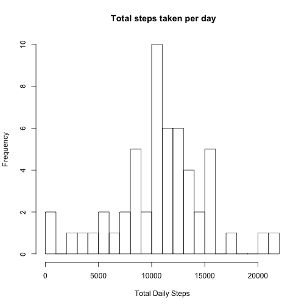

```r
total.steps <- as.numeric(tapply(data$steps, data$date, sum))
hist(total.steps, breaks = 20, xlab = "Total Daily Steps", main = " Total steps taken per day")
```

Calculte the **mean** and **median** of total number of steps taken per day.

```r
mean(total.steps, na.rm = TRUE)
median(total.steps, na.rm = TRUE)
```

```
## [1] 10766
```

```
## [1] 10765
```

## What is the average daily activity pattern?

Calculate the average number of steps taken per 5-minute interval and put into a dataframe.

```r
mean.interval <- tapply(data$steps, data$interval, mean, na.rm = TRUE)
avg.steps <- data.frame(cbind(data$interval, mean.interval))
colnames(avg.steps) <- c("interval", "steps")
```

Make a time series plot of the 5-minute interval (x-axis) and average number of steps taken, averaged across all days (y-axis).

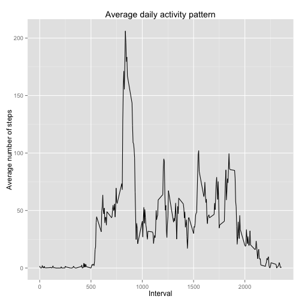

```r
library(ggplot2)
p <- ggplot(avg.steps, aes(interval,steps)) + geom_line()
pp <- p + labs((list(title = "Average daily activity pattern", x = "Interval", y = "Average number of steps")))
print(pp)
```

Find the 5-minute interval which contains the maximum number of steps.

```r
max.interval <- avg.steps[which.max(avg.steps$steps), ]
max.interval
```

```
##     interval steps
## 104      835 206.2
```

## Imputing missing values

Calculate the total number of missing values (NA) in the dataset.

```r
miss <- sum(is.na(data$steps)); miss
```

```
## [1] 2304
```

Use the mean for the 5-minute interval to fill in the missing values in dataset.

```r
newdata <- data
newdata[is.na(newdata[,1]),1] <- avg.steps[is.na(newdata[, 1]), 2]
```

Make a histogram of the total number of steps taken each day with the new dataset.

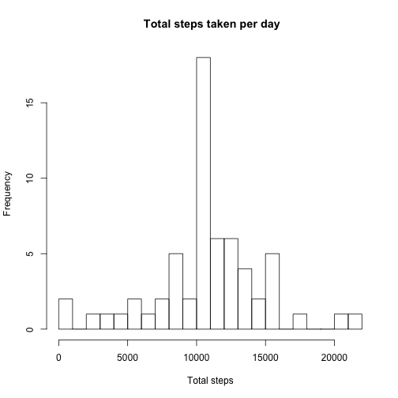

```r
hist(tapply(newdata$steps, newdata$date, sum), breaks = 20, xlab = "Total steps", main = " Total steps taken per day")
```

Calculate the **mean** and **median** total number of steps taken per day.

```r
mean(tapply(newdata$steps, newdata$date, sum))
median(tapply(newdata$steps, newdata$date, sum))
```

```
## [1] 10766
```

```
## [1] 10766
```

## Are there differences in activity patterns between weekdays and weekends?

Create a new factor variable with two levels (i.e. day) to indicate if the day is a weekend or weekday.

```r
newdata$day <- as.factor(ifelse(weekdays(newdata$date) %in% c("Saturday", "Sunday"),
                                "weekend", "weekday"))
```

Make a time series plot of the 5-minute interval (x-axis) and the average number of steps taken, averaged across all weekdays or weekend days(y-axis).

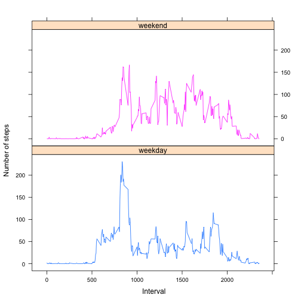

```r
library(lattice)
xyplot(steps ~ interval | day, aggregate(steps ~ interval + day, newdata, mean),
       layout = c(1, 2), type = "l", group = day, xlab = " Interval" , ylab = "Number of steps")
```

The graph shows that acitivity on the weekday has a greater peak from average number of steps taken on a given time interval. However, the weekend shows a greater distribution of steps taken over all intervals. This could be a clear indication that more activity is taken place during the weekend.